# Project: Investigate a Dataset - [TMDb movie data]

- Introduction
- Data Wrangling
- Exploratory Data Analysis
- Conclusions

# Introduction

## Dataset Description

This data set contains information about 10,000 movies collected from The Movie Database (TMDb), including user ratings and revenue. This dataset include under fields:

- **id:** This is the unique identifier for each movie in the dataset.
- **imdb_id:** The IMDb ID of the movie, which is a unique identifier used by the The Movie Database.
- **popularity:** A measure of how popular the movie is
- **budget** The budget of the movie
- **revenue** The revenue earned by the movie
- **original_title:** The original title of the movie.
- **cast:** The main actors and actresses who appear in the movie.
- **homepage:** The website URL associated with the movie, if available.
- **director:** The director(s) of the movie.
- **tagline:** A memorable phrase or slogan associated with the movie, often used in marketing campaigns.
- **overview:** A brief summary or description of the movie's plot or storyline.
- **runtime:** The duration of the movie in minutes.
- **genres:** The genre(s) of the movie, such as action, comedy, drama, etc.
- **production_companies:** The production companies involved in making the movie.
- **release_date:** The date when the movie was released in theaters or made available to the public.
- **vote_count:** The number of votes or ratings received by the movie.
- **vote_average:** The average rating of the movie based on user votes.
- **release_year:** The year when the movie was released.
- **budget_adj:** The budget of the movie adjusted for inflation, usually to a common base year for comparison purposes.
- **revenue_adj:** The revenue earned by the movie adjusted for inflation, usually to a common base year for comparison purposes.

## Question(s) for Analysis

1. **Seasonal Trends**
- Are there any seasonal trends in movie releases or revenue generation?
- Do movies released during certain times of the year tend to perform better?
2. **Financial Analysis**
- Is there a correlation between a movie's budget and its revenue? Are high-budget movies more likely to generate higher revenue?
- How does adjusting for inflation affect the comparison of budget and revenue across different years?
3. **Genre Analysis**
- Which genres tend to have the highest average revenue or popularity?
- Are there any genres that consistently perform well financially, regardless of other factors?
4. **Runtime Analysis**
- How does the runtime of a movie correlate with its popularity or financial performance?
- Are there any trends in movie runtimes over the years?
- Which genres tend to have long or short runtime?
5. **User Engagement and Popularity**
- Is there a correlation between user engagement (vote count) and financial performance?
- Is there a correlation between user engagement (vote count) and movie popularity?
- Is there a correlation between a movie's popularity and its revenue?
6. **Marketing and Promotion**
- Is there a relationship between having a homepage and a movie's success?
- What are the most frequently mentioned keywords?
- Which keywords are associated with higher financial performance in movies?

```python
import pandas as pd
import numpy as np
import seaborn as sns
import matplotlib.pyplot as plt
from IPython.display import display, HTML
```

```python
pd.set_option('display.max_columns', None)  # Display all columns
```

# Data Wrangling

## 📂 General Properties

```python
#Load your data and print out a few lines
df = pd.read_csv('Database_TMDb_movie_data/tmdb-movies.csv')
```

```python
df.head(4)
```

|  | id | imdb_id | popularity | budget | revenue | original_title | cast | homepage | director | tagline | keywords | overview | runtime | genres | production_companies | release_date | vote_count | vote_average | release_year | budget_adj | revenue_adj |
| --- | --- | --- | --- | --- | --- | --- | --- | --- | --- | --- | --- | --- | --- | --- | --- | --- | --- | --- | --- | --- | --- |
| 0 | 135397 | tt0369610 | 32.985763 | 150000000 | 1513528810 | Jurassic World | Chris Pratt\|Bryce Dallas Howard\|Irrfan Khan\|Vi... | http://www.jurassicworld.com/ | Colin Trevorrow | The park is open. | monster\|dna\|tyrannosaurus rex\|velociraptor\|island | Twenty-two years after the events of Jurassic ... | 124 | Action\|Adventure\|Science Fiction\|Thriller | Universal Studios\|Amblin Entertainment\|Legenda... | 6/9/15 | 5562 | 6.5 | 2015 | 1.379999e+08 | 1.392446e+09 |
| 1 | 76341 | tt1392190 | 28.419936 | 150000000 | 378436354 | Mad Max: Fury Road | Tom Hardy\|Charlize Theron\|Hugh Keays-Byrne\|Nic... | http://www.madmaxmovie.com/ | George Miller | What a Lovely Day. | future\|chase\|post-apocalyptic\|dystopia\|australia | An apocalyptic story set in the furthest reach... | 120 | Action\|Adventure\|Science Fiction\|Thriller | Village Roadshow Pictures\|Kennedy Miller Produ... | 5/13/15 | 6185 | 7.1 | 2015 | 1.379999e+08 | 3.481613e+08 |
| 2 | 262500 | tt2908446 | 13.112507 | 110000000 | 295238201 | Insurgent | Shailene Woodley\|Theo James\|Kate Winslet\|Ansel... | http://www.thedivergentseries.movie/#insurgent | Robert Schwentke | One Choice Can Destroy You | based on novel\|revolution\|dystopia\|sequel\|dyst... | Beatrice Prior must confront her inner demons ... | 119 | Adventure\|Science Fiction\|Thriller | Summit Entertainment\|Mandeville Films\|Red Wago... | 3/18/15 | 2480 | 6.3 | 2015 | 1.012000e+08 | 2.716190e+08 |
| 3 | 140607 | tt2488496 | 11.173104 | 200000000 | 2068178225 | Star Wars: The Force Awakens | Harrison Ford\|Mark Hamill\|Carrie Fisher\|Adam D... | http://www.starwars.com/films/star-wars-episod... | J.J. Abrams | Every generation has a story. | android\|spaceship\|jedi\|space opera\|3d | Thirty years after defeating the Galactic Empi... | 136 | Action\|Adventure\|Science Fiction\|Fantasy | Lucasfilm\|Truenorth Productions\|Bad Robot | 12/15/15 | 5292 | 7.5 | 2015 | 1.839999e+08 | 1.902723e+09 |

```python
#the size of dataframe
df.shape
```

```
(10866, 21)
```

```python
#data types and look for instances of missing and columns's data types
df.info()
```

```
<class 'pandas.core.frame.DataFrame'>
RangeIndex: 10866 entries, 0 to 10865
Data columns (total 21 columns):
 #   Column                Non-Null Count  Dtype
---  ------                --------------  -----
 0   id                    10866 non-null  int64
 1   imdb_id               10856 non-null  object
 2   popularity            10866 non-null  float64
 3   budget                10866 non-null  int64
 4   revenue               10866 non-null  int64
 5   original_title        10866 non-null  object
 6   cast                  10790 non-null  object
 7   homepage              2936 non-null   object
 8   director              10822 non-null  object
 9   tagline               8042 non-null   object
 10  keywords              9373 non-null   object
 11  overview              10862 non-null  object
 12  runtime               10866 non-null  int64
 13  genres                10843 non-null  object
 14  production_companies  9836 non-null   object
 15  release_date          10866 non-null  object
 16  vote_count            10866 non-null  int64
 17  vote_average          10866 non-null  float64
 18  release_year          10866 non-null  int64
 19  budget_adj            10866 non-null  float64
 20  revenue_adj           10866 non-null  float64
dtypes: float64(4), int64(6), object(11)
memory usage: 1.7+ MB
```

Several columns contain missing values, including: imdb_id, cast, homepage, director, tagline, keywords, overview, genres, and production_companies. Additionally, some columns exhibit inappropriate data types, which necessitates conversion during the cleaning process.

```python
df.describe()
```

|  | id | popularity | budget | revenue | runtime | vote_count | vote_average | release_year | budget_adj | revenue_adj |
| --- | --- | --- | --- | --- | --- | --- | --- | --- | --- | --- |
| count | 10866.000000 | 10866.000000 | 1.086600e+04 | 1.086600e+04 | 10866.000000 | 10866.000000 | 10866.000000 | 10866.000000 | 1.086600e+04 | 1.086600e+04 |
| mean | 66064.177434 | 0.646441 | 1.462570e+07 | 3.982332e+07 | 102.070863 | 217.389748 | 5.974922 | 2001.322658 | 1.755104e+07 | 5.136436e+07 |
| std | 92130.136561 | 1.000185 | 3.091321e+07 | 1.170035e+08 | 31.381405 | 575.619058 | 0.935142 | 12.812941 | 3.430616e+07 | 1.446325e+08 |
| min | 5.000000 | 0.000065 | 0.000000e+00 | 0.000000e+00 | 0.000000 | 10.000000 | 1.500000 | 1960.000000 | 0.000000e+00 | 0.000000e+00 |
| 25% | 10596.250000 | 0.207583 | 0.000000e+00 | 0.000000e+00 | 90.000000 | 17.000000 | 5.400000 | 1995.000000 | 0.000000e+00 | 0.000000e+00 |
| 50% | 20669.000000 | 0.383856 | 0.000000e+00 | 0.000000e+00 | 99.000000 | 38.000000 | 6.000000 | 2006.000000 | 0.000000e+00 | 0.000000e+00 |
| 75% | 75610.000000 | 0.713817 | 1.500000e+07 | 2.400000e+07 | 111.000000 | 145.750000 | 6.600000 | 2011.000000 | 2.085325e+07 | 3.369710e+07 |
| max | 417859.000000 | 32.985763 | 4.250000e+08 | 2.781506e+09 | 900.000000 | 9767.000000 | 9.200000 | 2015.000000 | 4.250000e+08 | 2.827124e+09 |

Upon examining the descriptive statistics of the table, anomalies become apparent in several fields:

- In the "popularity" and "vote_count" column, an unusually high maximum value is observed.
- Concerning "budget," "revenue," and "runtime," instances of zero values are present, which are incongruous and lack logical coherence.

Subsequently, we will delve into the exploration of these anomalies and outliers.

## 📋 Data Cleaning

In this process, we will undergo several steps:

1. **Duplicate Checking:** We will examine the dataset to identify any duplicate values and subsequently remove them.
2. **Addressing Missing Values:** Here, we will identify columns containing missing values. We'll then address these missing values by either filling them with appropriate values or removing the entries altogether. The approach taken will depend on the specific circumstances and adhere to business rules.
3. **Inconsistent Text and Typos:** We'll check for inconsistencies and typos in the dataset. If any values are found to have typos, we will rewrite or replace them with the correct values based on either the actual value or predefined business rules. For instance, in cases where revenue or budget values are missing (equal to 0), we will fill them with the average value.
4. **Checking Data Types:** We will assess the data types of each column and decide whether any changes are necessary.
5. **Exclude irrelevant columns:** We will exclude columns that are not required for our analysis and questions.

**Note:** There are various approaches to correcting erroneous values based on business rules or stakeholder requirements. However, in this scenario, I will proceed based on my own judgment since no specific business rules or requirements have been provided.

### Duplicate Checking

```python
df[df.duplicated(keep=False)]
```

|  | id | imdb_id | popularity | budget | revenue | original_title | cast | homepage | director | tagline | keywords | overview | runtime | genres | production_companies | release_date | vote_count | vote_average | release_year | budget_adj | revenue_adj |
| --- | --- | --- | --- | --- | --- | --- | --- | --- | --- | --- | --- | --- | --- | --- | --- | --- | --- | --- | --- | --- | --- |
| 2089 | 42194 | tt0411951 | 0.59643 | 30000000 | 967000 | TEKKEN | Jon Foo\|Kelly Overton\|Cary-Hiroyuki Tagawa\|Ian... | NaN | Dwight H. Little | Survival is no game | martial arts\|dystopia\|based on video game\|mart... | In the year of 2039, after World Wars destroy ... | 92 | Crime\|Drama\|Action\|Thriller\|Science Fiction | Namco\|Light Song Films | 3/20/10 | 110 | 5.0 | 2010 | 30000000.0 | 967000.0 |
| 2090 | 42194 | tt0411951 | 0.59643 | 30000000 | 967000 | TEKKEN | Jon Foo\|Kelly Overton\|Cary-Hiroyuki Tagawa\|Ian... | NaN | Dwight H. Little | Survival is no game | martial arts\|dystopia\|based on video game\|mart... | In the year of 2039, after World Wars destroy ... | 92 | Crime\|Drama\|Action\|Thriller\|Science Fiction | Namco\|Light Song Films | 3/20/10 | 110 | 5.0 | 2010 | 30000000.0 | 967000.0 |

```python
# Drop duplicated
df.drop_duplicates(inplace=True)
```

```python
df.duplicated().sum()
```

```
0
```

### Addressing Missing Values

There are missing values in: imdb_id, cast, homepage, director, tagline, keywords, overview, genres, and production_companies column.

```python
df.isna().sum()
```

```
id                         0
imdb_id                   10
popularity                 0
budget                     0
revenue                    0
original_title             0
cast                      76
homepage                7929
director                  44
tagline                 2824
keywords                1493
overview                   4
runtime                    0
genres                    23
production_companies    1030
release_date               0
vote_count                 0
vote_average               0
release_year               0
budget_adj                 0
revenue_adj                0
dtype: int64
```

```python
# Fill missing value
df['cast'].fillna('Missing',inplace=True)
df['director'].fillna('Missing',inplace=True)
df['tagline'].fillna('N/A',inplace=True)
df['keywords'].fillna('N/A',inplace=True)
df['genres'].fillna('Unkown',inplace=True)
df['production_companies'].fillna('Missing',inplace=True)
```

```python
# Drop irelverent columns
irelverent_columns = ['imdb_id','overview']
df = df.drop(columns=irelverent_columns)
```

```python
# Convert homepage column: if movie has hompage then 1, else 0
df['homepage'] = np.where(df['homepage'].isna(),0,1)
```

After filling missing values, dropping columns, and converting columns, there should be no missing values remaining.

### Inconsistent Text and Typos

As we've seen earlier, there are some values equal to 0 in the budget,revenue and budget_adj, revenue_adj columns. We'll assume these are errors, and we'll address them by replacing them with the mean value

```python
# Caculate average budget and revenue
filter_budget = df[df['budget'] > 0]
filter_revenue = df[df['revenue'] > 0 ]

avg_budget = filter_budget['budget'].mean()
avg_revenue = filter_revenue['revenue'].mean()
# Replace 0 value with avg value
df['budget'] = np.where(df['budget'] == 0, avg_budget, df['budget'])
df['revenue'] = np.where(df['revenue'] == 0, avg_revenue, df['revenue'])
```

```python
# Caculate average budget and revenue
filter_budget_adj = df[df['budget_adj'] > 0]
filter_revenue_adj = df[df['revenue_adj'] > 0 ]

avg_budget_adj = filter_budget_adj['budget_adj'].mean()
avg_revenue_adj = filter_revenue_adj['revenue_adj'].mean()
# Replace 0 value with avg value
df['budget_adj'] = np.where(df['budget_adj'] == 0, avg_budget_adj, df['budget_adj'])
df['revenue_adj'] = np.where(df['revenue_adj'] == 0, avg_revenue_adj, df['revenue_adj'])
```

### Checking Data Types

```python
df.dtypes
```

```
id                        int64
popularity              float64
budget                  float64
revenue                 float64
original_title           object
cast                     object
homepage                  int64
director                 object
tagline                  object
keywords                 object
runtime                   int64
genres                   object
production_companies     object
release_date             object
vote_count                int64
vote_average            float64
release_year              int64
budget_adj              float64
revenue_adj             float64
dtype: object
```

I should have converted the 'release_date' column to datetime. However, in this case, it is in the format such as 3/13/10, so it is difficult to determine whether it is the year 1910 or 2010 during conversion. Since we already have the 'year' column available, I will keep it unchanged and not convert it to datetime.

### Exclude irrelevant columns

```python
irelverent_columns = ['cast','director','tagline','production_companies']
df = df.drop(columns=irelverent_columns)
```

# Exploratory Data Analysis

During this exploratory data analysis (EDA) process, we will undertake the following steps:

1. **Feature Engineering (Creating New Columns):**
   - Creating the **Release Month feature** to analyze movie releases by seasonal and monthly patterns.
   - Creating the **Net Profit feature** to analyze the profitability of movies.
2. **Exploration:**
- Exploring dataset features through **aggregation**.
- Utilizing **visualizations** to gain deeper insights into the data.

## 📂 Creating new columns

```python
# Create month feature
df['release_month'] = pd.to_datetime(df['release_date']).dt.month
```

```python
# Create net_profit feature
df['net_profit'] = df['revenue'] - df['budget']
```

```python
df.head()
```

|  | id | popularity | budget | revenue | original_title | homepage | keywords | runtime | genres | release_date | vote_count | vote_average | release_year | budget_adj | revenue_adj | release_month | net_profit |
| --- | --- | --- | --- | --- | --- | --- | --- | --- | --- | --- | --- | --- | --- | --- | --- | --- | --- |
| 0 | 135397 | 32.985763 | 150000000.0 | 1.513529e+09 | Jurassic World | 1 | monster\|dna\|tyrannosaurus rex\|velociraptor\|island | 124 | Action\|Adventure\|Science Fiction\|Thriller | 6/9/15 | 5562 | 6.5 | 2015 | 1.379999e+08 | 1.392446e+09 | 6 | 1.363529e+09 |
| 1 | 76341 | 28.419936 | 150000000.0 | 3.784364e+08 | Mad Max: Fury Road | 1 | future\|chase\|post-apocalyptic\|dystopia\|australia | 120 | Action\|Adventure\|Science Fiction\|Thriller | 5/13/15 | 6185 | 7.1 | 2015 | 1.379999e+08 | 3.481613e+08 | 5 | 2.284364e+08 |
| 2 | 262500 | 13.112507 | 110000000.0 | 2.952382e+08 | Insurgent | 1 | based on novel\|revolution\|dystopia\|sequel\|dyst... | 119 | Adventure\|Science Fiction\|Thriller | 3/18/15 | 2480 | 6.3 | 2015 | 1.012000e+08 | 2.716190e+08 | 3 | 1.852382e+08 |
| 3 | 140607 | 11.173104 | 200000000.0 | 2.068178e+09 | Star Wars: The Force Awakens | 1 | android\|spaceship\|jedi\|space opera\|3d | 136 | Action\|Adventure\|Science Fiction\|Fantasy | 12/15/15 | 5292 | 7.5 | 2015 | 1.839999e+08 | 1.902723e+09 | 12 | 1.868178e+09 |
| 4 | 168259 | 9.335014 | 190000000.0 | 1.506249e+09 | Furious 7 | 1 | car race\|speed\|revenge\|suspense\|car | 137 | Action\|Crime\|Thriller | 4/1/15 | 2947 | 7.3 | 2015 | 1.747999e+08 | 1.385749e+09 | 4 | 1.316249e+09 |

## 📂 Answer Questions

**Question 1: Seasonal Trends**

- Are there any seasonal trends in movie releases or revenue generation?
- Do movies released during certain times of the year tend to perform better?

```python
monthly_data = df.groupby('release_month').agg({'revenue':'sum','net_profit':'sum','id':'count'}).reset_index()
```

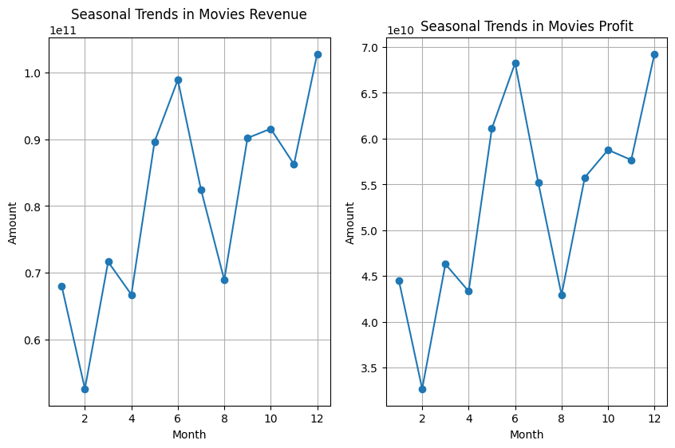

```python
plt.figure(figsize=(10, 6))
# Create firt chart
plt.subplot(1,2,1)
plt.plot(monthly_data['release_month'], monthly_data['revenue'], marker='o', label='Total Revenue')
plt.title('Seasonal Trends in Movies Revenue')
plt.xlabel('Month')
plt.ylabel('Amount')
plt.grid(True)

# Create second chart
plt.subplot(1,2,2)
plt.plot(monthly_data['release_month'], monthly_data['net_profit'], marker='o', label='Net Profit')
plt.title('Seasonal Trends in Movies Profit')
plt.xlabel('Month')
plt.ylabel('Amount')
plt.grid(True)
```

**Revenue Trends:**

- Revenue is high in June and reaches its peak in December, likely due to increased moviegoing during the holiday season.
- The lowest revenue is observed in February, possibly due to lower audience turnout during this period.

**Net Profit Trends:**

Overall, the data suggests seasonal variations in both revenue and net profit, with June and December emerging as the most lucrative months for the movie industry.

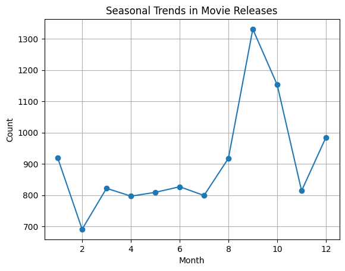

```python
plt.plot(monthly_data['release_month'], monthly_data['id'], marker='o',label='Number of Movies')
plt.title('Seasonal Trends in Movie Releases')
plt.xlabel('Month')
plt.ylabel('Count')
plt.grid(True)
```

In contrast to revenue and budget, the chart reveals that the highest number of movie releases occurs in September.

**September Release Peak:** Although September sees the highest number of movie releases, it doesn't always translate to the highest revenue or budget. This could be due to various reasons such as increased competition among releases, audience fatigue from summer blockbusters, or the nature of the movies released (e.g., lower-budget films, niche genres).

**Audience Behavior and Preferences:** Audience behavior and preferences play a crucial role in determining box office performance. Factors such as school holidays, major events, and weather conditions can influence when audiences are more likely to go to the movies, impacting revenue trends independently of release numbers.

In summary, while there may be differences in the number of movie releases across months, revenue and net_profit are influenced by various factors beyond just release numbers. High-profile releases, strategic marketing, audience preferences, and external factors all contribute to the observed trends in revenue and budget.

**Question 2: Financial Analysis**

- Is there a correlation between a movie's budget and its revenue? Are high-budget movies more likely to generate higher revenue?
- How does adjusting for inflation affect the comparison of budget and revenue across different years?

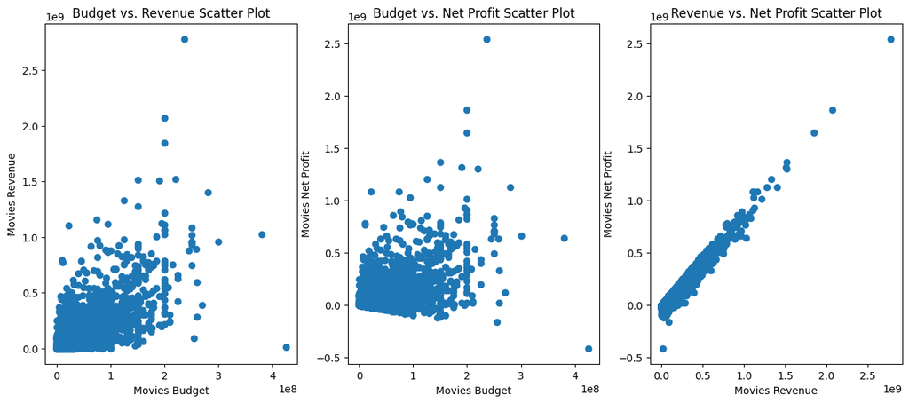

```python
# Drawing Scatter Plot
plt.figure(figsize=(15, 6))
plt.subplot(1,3,1)
plt.scatter(data=df, x='budget',y='revenue')
plt.title('Budget vs. Revenue Scatter Plot')
plt.xlabel('Movies Budget')
plt.ylabel('Movies Revenue')

plt.subplot(1,3,2)
plt.scatter(data=df, x='budget',y='net_profit')
plt.title('Budget vs. Net Profit Scatter Plot')
plt.xlabel('Movies Budget')
plt.ylabel('Movies Net Profit')

plt.subplot(1,3,3)
plt.scatter(data=df, x='revenue',y='net_profit')
plt.title('Revenue vs. Net Profit Scatter Plot')
plt.xlabel('Movies Revenue')
plt.ylabel('Movies Net Profit');
```

```python
df.loc[:,('budget','revenue','net_profit')].corr()
```

|  | budget | revenue | net_profit |
| --- | --- | --- | --- |
| budget | 1.000000 | 0.640895 | 0.455776 |
| revenue | 0.640895 | 1.000000 | 0.975367 |
| net_profit | 0.455776 | 0.975367 | 1.000000 |

Base on ScatterPlot and correlation we have conclusion that:

**The correlation between budget and net_profit is 0.4557.**

This correlation coefficient indicates a moderate **positive correlation** between budget and net_profit. As the budget for a movie increases, there tends to be a moderate increase in the net_profit, but the relationship is **not extremely strong**.

**The correlation between budget and revenue is 0.6408.**

This correlation coefficient indicates a moderate **positive correlation** between budget and revenue. As the budget for a movie increases, there tends to be a moderate increase in the revenue, suggesting that a higher budget generally results in higher revenue, but the relationship is **not extremely strong**.

**The correlation between revenue and net_profit is 0.975.**

This correlation coefficient indicates a very **strong positive correlation** between revenue and net_profit. As the revenue of a movie increases, there is a very strong tendency for the net_profit generated by the movie to also increase proportionally. This suggests that a higher revenue is highly predictive of higher net_profit.

**Note:** remember that correlation does not imply causation, and other factors may also influence the revenue of a movie.

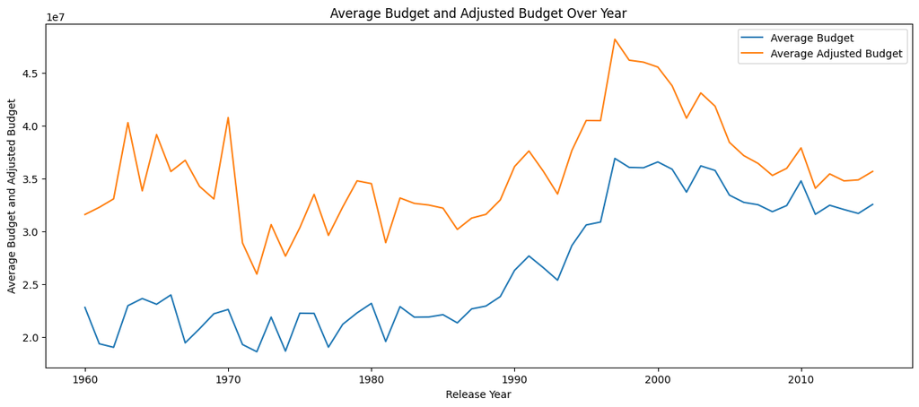

```python
# Caculate avg budget and adjusted budget by years
budget_by_year = df.groupby('release_year')['budget'].mean()
budget_adj_by_year = df.groupby('release_year')['budget_adj'].mean()
# Set figure
plt.figure(figsize=(15, 6))
#Create plot for Average Budget and Adjusted Budget  Over Year
plt.plot(budget_by_year.index, budget_by_year.values, label='Average Budget')
plt.plot(budget_adj_by_year.index, budget_adj_by_year.values, label='Average Adjusted Budget')
plt.title('Average Budget and Adjusted Budget Over Year')
plt.xlabel('Release Year')
plt.ylabel('Average Budget and Adjusted Budget')
plt.legend();
```

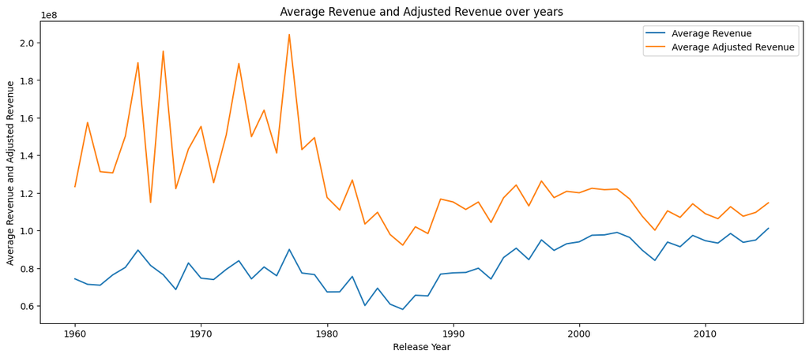

```python
# Caculate avg for revenue and adjusted revenue
revenue_over_year = df.groupby('release_year')['revenue'].mean()
revenue_adj_over_year = df.groupby('release_year')['revenue_adj'].mean()
#Set figure
plt.figure(figsize=(15,6))
# Create plot for AVG Revenue over years
plt.plot(revenue_over_year.index, revenue_over_year.values, label='Average Revenue')
plt.plot(revenue_adj_over_year.index, revenue_adj_over_year.values, label='Average Adjusted Revenue')
plt.xlabel('Release Year')
plt.ylabel('Average Revenue and Adjusted Revenue')
plt.title('Average Revenue and Adjusted Revenue over years')
plt.legend()
```

The shapes of the average budget and average adjusted budget lines are quite similar, except for differences observed between 1960 and 1980. Similarly, the shapes of the average revenue and average adjusted revenue lines exhibit similar patterns. The significant changes in the shape of adjusted budget and revenue values during the 1960s to 1980s maybe stem from broader economic and industry-specific influences on film production.

Historical events, economic trends, and technological advancements may have driven fluctuations in production costs and budget allocation, thereby impacting the comparison of budget and revenue across different years.

Adjusting for inflation enables more accurate comparisons by accounting for changes in the value of money over time, allowing researchers to contextualize budget and revenue data within broader economic and historical contexts.

**Question 3: Genre Analysis**

- Which genres tend to have the highest average revenue, net profit or popularity?
- Which genres tend to have the highest or the lowest budget?

```python
# Split genres
genres_split = df['genres'].str.split('|', expand=True)
# Concatnate genres with release_year,revenue, budget, popularity, net_profit
genres_info = pd.concat([df['release_year'],df['revenue'], df['budget'],df['popularity'],df['net_profit'] ,genres_split], axis=1)
genres_data = pd.melt(genres_info, id_vars=['release_year', 'revenue', 'budget','popularity','net_profit'], value_vars=[0, 1, 2, 3, 4], value_name='genre').dropna()
```

```python
# Create function to find top 5 highest of each element
def genre_top5_analysis(input_df, grby_col, agg_col = None, sort_col = None):
    sorted_df = pd.DataFrame()
    if agg_col is not None:
        agg_df = input_df.groupby(grby_col)[agg_col].mean().reset_index()
        sorted_df = agg_df.sort_values(sort_col, ascending=False).head(5)
    else:
        agg_df = input_df.groupby(grby_col).count().reset_index()
        sorted_df = agg_df.sort_values(sort_col, ascending=False).head(5)
    return sorted_df
```

```python
# Top 5 highest revenue
top_5_highest_revenue_genre    = genre_top5_analysis(genres_data, 'genre', 'revenue', 'revenue')

# Top 5 highest net_profit
top_5_highest_net_profit_genre = genre_top5_analysis(genres_data, 'genre', 'net_profit', 'net_profit')

# Top 5 highest popularity
top_5_highest_popularity_genre = genre_top5_analysis(genres_data, 'genre', 'popularity', 'popularity')

# Top 5 highest budget
top_5_highest_budget_genre     = genre_top5_analysis(genres_data, 'genre', 'budget', 'budget')

# Top 5 created genre
top_5_most_created_genre       = genre_top5_analysis(genres_data, 'genre', None, 'revenue')

# Top 5 lowest budget
avg_budget_by_genre            = genres_data.groupby('genre')['budget'].mean().reset_index()
top_5_lowest_budget_genre      = avg_budget_by_genre.sort_values('budget').head(5)
```

```python
# Define the HTML template for displaying DataFrame with a name
template = """
<div style="float: left; padding-right: 20px;">
    <h3>{name}</h3>
    {data}
</div>
"""
```

```python
# Display df of top 5 highest revenue, budget and popularity
display(HTML(template.format(name='Top 5 Highest Revenue Genres', data=top_5_highest_revenue_genre.to_html(index=False))),
        HTML(template.format(name='Top 5 Highest Net Profit Genres', data=top_5_highest_net_profit_genre.to_html(index=False))),
        HTML(template.format(name='Top 5 Highest Popularity Genres', data=top_5_highest_popularity_genre.to_html(index=False))))
```

Top 5 Highest Revenue Genres

| genre | revenue |
| --- | --- |
| Adventure | 1.512358e+08 |
| Fantasy | 1.406408e+08 |
| Animation | 1.342380e+08 |
| Family | 1.244831e+08 |
| Science Fiction | 1.168294e+08 |

Top 5 Highest Net Profit Genres

| genre | net_profit |
| --- | --- |
| Adventure | 1.018852e+08 |
| Fantasy | 9.433637e+07 |
| Animation | 9.177250e+07 |
| Family | 8.344417e+07 |
| Science Fiction | 7.865046e+07 |

Top 5 Highest Popularity Genres

| genre | popularity |
| --- | --- |
| Adventure | 1.154259 |
| Science Fiction | 1.001548 |
| Fantasy | 0.992840 |
| Action | 0.926274 |
| Animation | 0.852182 |

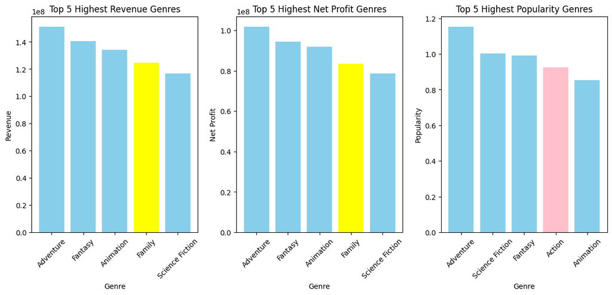

```python
# Create Chart for top 5 highest Revenue, Net Profit and Popularity
plt.figure(figsize=(12, 6))
colors1 = ['skyblue', 'skyblue', 'skyblue', 'yellow', 'skyblue']
colors2 = ['skyblue', 'skyblue', 'skyblue', 'pink', 'skyblue']
# Subplot 1: Top 5 Highest Revenue Genres
plt.subplot(1, 3, 1)
plt.bar(top_5_highest_revenue_genre['genre'], top_5_highest_revenue_genre['revenue'], color=colors1)
plt.xlabel('Genre')
plt.ylabel('Revenue')
plt.title('Top 5 Highest Revenue Genres')
plt.xticks(rotation=45)

# Subplot 2: Top 5 Highest Net Profit Genres
plt.subplot(1, 3, 2)
plt.bar(top_5_highest_net_profit_genre['genre'], top_5_highest_net_profit_genre['net_profit'], color=colors1)
plt.xlabel('Genre')
plt.ylabel('Net Profit')
plt.title('Top 5 Highest Net Profit Genres')
plt.xticks(rotation=45)

# Subplot 3: Top 5 Highest Popularity Genres
plt.subplot(1, 3, 3)
plt.bar(top_5_highest_popularity_genre['genre'], top_5_highest_popularity_genre['popularity'], color=colors2)
plt.xlabel('Genre')
plt.ylabel('Popularity')
plt.title('Top 5 Highest Popularity Genres')
plt.xticks(rotation=45)

plt.tight_layout()
plt.show()
```

The charts above display the top 5 highest in revenue, net profit, and popularity.

The **highest revenue and net_profit** genre is Adventure, followed by Fantasy, Animation, Family, and Science Fiction. However, in terms of popularity, the Family genre is replaced by Action.

This indicates that while the **family genre** boasts higher revenue and net profit, the **action genre** enjoys greater popularity.

```python
display(HTML(template.format(name='Top 5 Highest Budget Genres', data=top_5_highest_budget_genre.to_html(index=False))),
        HTML(template.format(name='Top 5 Lowest Budget Genres', data=top_5_lowest_budget_genre.to_html(index=False))))
```

Top 5 Highest Budget Genres

| genre | budget |
| --- | --- |
| Adventure | 4.935053e+07 |
| Fantasy | 4.630445e+07 |
| Animation | 4.246547e+07 |
| Family | 4.103896e+07 |
| Action | 4.005460e+07 |

Top 5 Lowest Budget Genres

| genre | budget |
| --- | --- |
| Horror | 2.260094e+07 |
| Foreign | 2.646822e+07 |
| Music | 2.744539e+07 |
| Documentary | 2.753339e+07 |
| Drama | 2.766381e+07 |

The movies with high budgets are adventure, fantasy, animation, family, and action movies. These are also the movies with high revenue, net profit, and popularity.

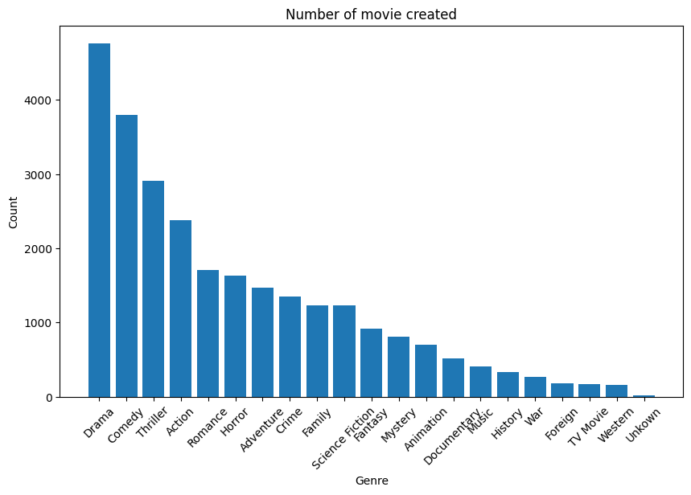

```python
genre_count = genres_data['genre'].value_counts().reset_index()
plt.figure(figsize=(10,6))
plt.bar(genre_count['index'], genre_count['genre'])
plt.xlabel('Genre')
plt.ylabel('Count')
plt.title('Number of movie created')
plt.xticks(rotation=45);
```

- **The most produced movies** over the years are **Dramas**. Although they are not among the top 5 highest in revenue, net profit, or popularity.
- Possibly, this genre is **the most produced** due to its relatively **low budget**, ranking among the top 5 genres with the lowest budgets.

**Question 4: Runtime Analysis**

- How does the runtime of a movie correlate with its popularity or revenue?
- Are there any trends in movie runtimes over the years?

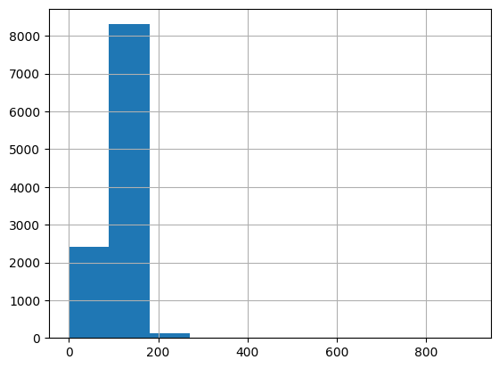

```python
# Plot histogram to understanding movie runtime distribution
df['runtime'].hist();
```

```python
df.loc[:,('runtime','budget','revenue','net_profit','popularity')].corr()
```

|  | runtime | budget | revenue | net_profit | popularity |
| --- | --- | --- | --- | --- | --- |
| runtime | 1.000000 | 0.133134 | 0.106851 | 0.085640 | 0.139032 |
| budget | 0.133134 | 1.000000 | 0.640895 | 0.455776 | 0.439929 |
| revenue | 0.106851 | 0.640895 | 1.000000 | 0.975367 | 0.570227 |
| net_profit | 0.085640 | 0.455776 | 0.975367 | 1.000000 | 0.534779 |
| popularity | 0.139032 | 0.439929 | 0.570227 | 0.534779 | 1.000000 |

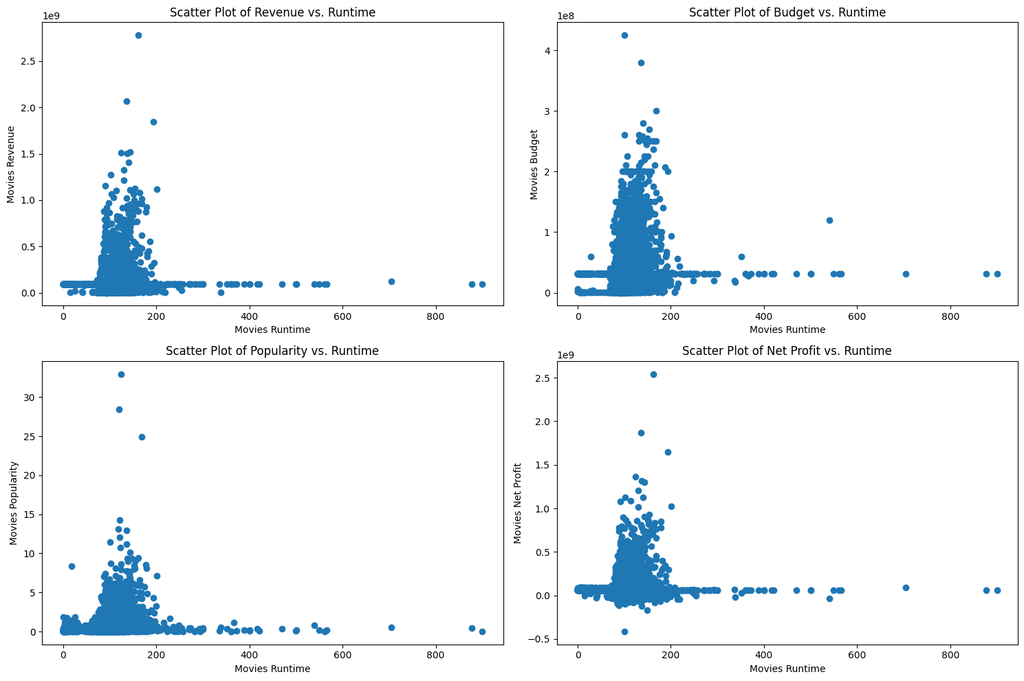

```python
# Drawing Scatter Plot
plt.figure(figsize=(15, 10))
plt.subplot(2, 2, 1)
plt.scatter(data=df, x='runtime', y='revenue')
plt.xlabel('Movies Runtime')
plt.ylabel('Movies Revenue')
plt.title('Scatter Plot of Revenue vs. Runtime')

plt.subplot(2, 2, 2)
plt.scatter(data=df, x='runtime', y='budget')
plt.xlabel('Movies Runtime')
plt.ylabel('Movies Budget')
plt.title('Scatter Plot of Budget vs. Runtime')

plt.subplot(2, 2, 3)
plt.scatter(data=df, x='runtime', y='popularity')
plt.xlabel('Movies Runtime')
plt.ylabel('Movies Popularity')
plt.title('Scatter Plot of Popularity vs. Runtime')

plt.subplot(2, 2, 4)
plt.scatter(data=df, x='runtime', y='net_profit')
plt.xlabel('Movies Runtime')
plt.ylabel('Movies Net Profit')
plt.title('Scatter Plot of Net Profit vs. Runtime')

plt.tight_layout()
plt.show()
```

Based on the correlation matrix and scatter plots, we observe that:

- There is almost no significant correlation between runtime and other factors such as revenue, net profit, or popularity.

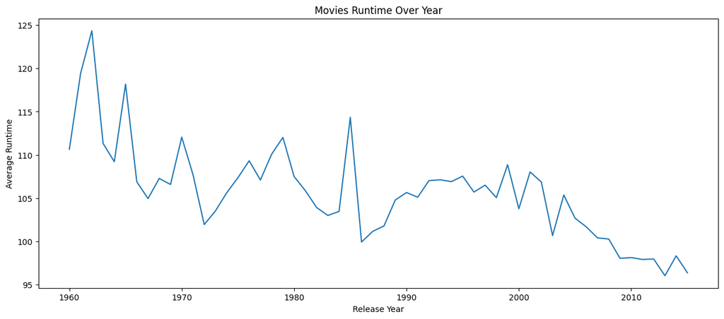

```python
avg_runtime_by_year = df.groupby('release_year')['runtime'].mean()

plt.figure(figsize=(15,6))
plt.plot(avg_runtime_by_year.index, avg_runtime_by_year.values)
plt.title('Movies Runtime Over Year')
plt.xlabel('Release Year')
plt.ylabel('Average Runtime');
```

In the graph, we observe a downward trend in movie runtime over the years.

```python
# Concat runtime with splited genre dataframe (in question 2: genre analysis)
runtime = pd.concat([df['runtime'], genres_split],axis=1)
genre_runtime = pd.melt(runtime, id_vars=['runtime'], value_vars=[0, 1, 2, 3, 4], value_name='genre').dropna()
# Caculate the avg runtime by genres
avg_runtime_by_genre = genre_runtime.groupby('genre')['runtime'].mean().reset_index()
```

```python
avg_runtime_by_genre.sort_values('runtime',ascending=False).head(3)
```

|  | genre | runtime |
| --- | --- | --- |
| 10 | History | 136.206587 |
| 19 | War | 127.625926 |
| 20 | Western | 117.575758 |

```python
avg_runtime_by_genre.sort_values('runtime',ascending=False).tail(4)
```

|  | genre | runtime |
| --- | --- | --- |
| 16 | TV Movie | 91.982036 |
| 7 | Family | 89.603574 |
| 18 | Unkown | 70.652174 |
| 2 | Animation | 68.181688 |

- The top 3 genres with the longest average runtime are: history, war, and western.
- The top 3 genres with the shortest average runtime are: TV movie, family, animation.

**Question 5: User Engagement and Popularity**

- Is there a correlation between user engagement (vote count) and popularity?
- Is there a correlation between user engagement (vote count) and financial performance (revenue, net profit)?
- Is there a correlation between a movie's popularity and its revenue?

```python
df.loc[:,('popularity','vote_count','revenue','net_profit')].corr()
```

|  | popularity | vote_count | revenue | net_profit |
| --- | --- | --- | --- | --- |
| popularity | 1.000000 | 0.800828 | 0.570227 | 0.534779 |
| vote_count | 0.800828 | 1.000000 | 0.715132 | 0.671784 |
| revenue | 0.570227 | 0.715132 | 1.000000 | 0.975367 |
| net_profit | 0.534779 | 0.671784 | 0.975367 | 1.000000 |

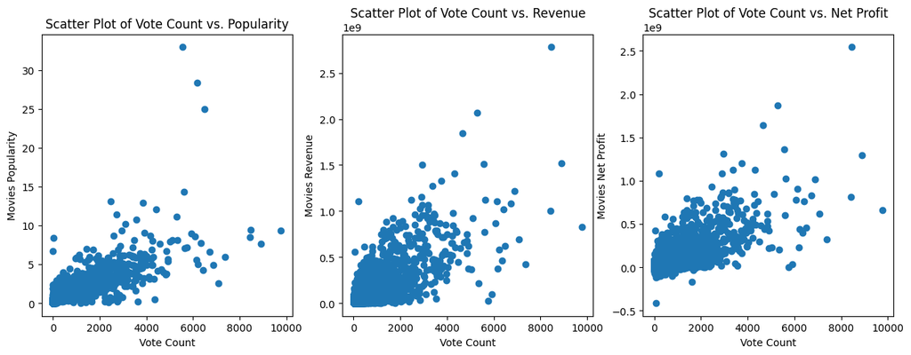

```python
plt.figure(figsize=(15,5))
plt.subplot(1,3,1)
plt.scatter(data=df, x='vote_count',y='popularity')
plt.xlabel('Vote Count')
plt.ylabel('Movies Popularity')
plt.title('Scatter Plot of Vote Count vs. Popularity')

plt.subplot(1,3,2)
plt.scatter(data=df, x='vote_count',y='revenue')
plt.xlabel('Vote Count')
plt.ylabel('Movies Revenue')
plt.title('Scatter Plot of Vote Count vs. Revenue')

plt.subplot(1,3,3)
plt.scatter(data=df, x='vote_count',y='net_profit')
plt.xlabel('Vote Count')
plt.ylabel('Movies Net Profit')
plt.title('Scatter Plot of Vote Count vs. Net Profit')
```

Base on ScatterPlot and correlation we have conclusion that:

- **Vote Count and Popularity**: There is a **strong positive** correlation (0.80) between popularity and vote count, indicating that movies with higher popularity tend to have more votes.
- **Vote Count and Revenue**: There is a **strong positive** correlation (0.72) between vote count and revenue, suggesting that movies with more votes tend to generate higher revenues.
- **Vote Count and Net Profit**: There is a **positive correlation** (0.67) between vote count and net profit, indicating that movies with more votes may also tend to have higher net profits.

**Question 6: Marketing and Promotion**

- Is there a relationship between having a homepage and a movie's success?
- Which keywords are associated with higher financial performance in movies?
- What are the most frequently mentioned keywords?

```python
df.groupby('homepage')[['popularity','revenue','net_profit','budget']].mean()
```

| homepage | popularity | revenue | net_profit | budget |
| --- | --- | --- | --- | --- |
| 0 | 0.515638 | 7.807858e+07 | 4.989559e+07 | 2.818299e+07 |
| 1 | 0.999706 | 1.193785e+08 | 8.173453e+07 | 3.764392e+07 |

**Movies with a homepage** tend to exhibit **higher** popularity, possibly due to increased marketing efforts associated with having a homepage.

Furthermore, **movies with a homepage** also tend to generate **higher revenue and net profit.**

In addition, **movies without a homepage** typically have **smaller budgets**, potentially reflecting reduced marketing expenditures.

```python
# Split keywords column
keyword_split = df['keywords'].str.split('|', expand=True)

# Create new df with revenue, budget, popularity, net_rofit and keywords
keyword_info  = pd.concat([df['revenue'],df['popularity'],df['net_profit'], keyword_split], axis=1)
keyword_data  = pd.melt(keyword_info, id_vars=['revenue', 'popularity','net_profit'], value_vars=[0, 1, 2, 3, 4], value_name='keywords').dropna()
```

```python
# With keywords have less than 100 times reminded, i will replace with 'Other'
keyword_counts                = keyword_data['keywords'].value_counts()
keyword_data['keyword_count'] = keyword_data['keywords'].map(keyword_counts)
keyword_data['keywords']      = np.where(keyword_data['keyword_count'] < 100, 'Other',keyword_data['keywords']  )
```

```python
keyword_sumarize = keyword_data.groupby('keywords')[['revenue','net_profit','popularity']].mean()
```

```python
# Sorted data before plot to make sure the highest value is on top of the graph
keyword_sumarize_sorted_revenue    = keyword_sumarize.sort_values('revenue', ascending=False)
keyword_sumarize_sorted_netprofit  = keyword_sumarize.sort_values('net_profit', ascending=False)
keyword_sumarize_sorted_popularity = keyword_sumarize.sort_values('popularity', ascending=False)

# Count keywords frequency exclude 'Other' and 'N/A'
keyword_frequency                  = keyword_data['keywords'].value_counts().drop(["Other", "N/A"])
```

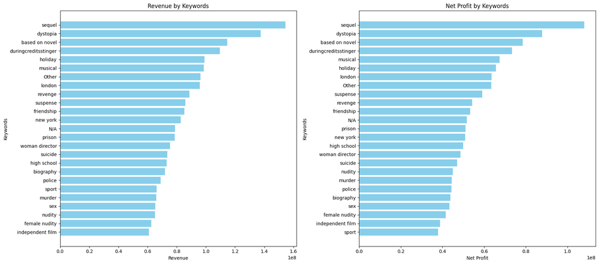

```python
plt.figure(figsize=(18, 8))

# Subplot1: Revenue by Keywords
plt.subplot(1, 2, 1)
plt.barh(keyword_sumarize_sorted_revenue.index, keyword_sumarize_sorted_revenue['revenue'], color='skyblue')
plt.xlabel('Revenue')
plt.ylabel('Keywords')
plt.title('Revenue by Keywords')
plt.gca().invert_yaxis()

# Subplot2: Net Profit by Ketwords
plt.subplot(1, 2, 2)
plt.barh(keyword_sumarize_sorted_netprofit.index, keyword_sumarize_sorted_netprofit['net_profit'], color='skyblue')
plt.xlabel('Net Profit')
plt.ylabel('Keywords')
plt.title('Net Profit by Keywords')
plt.gca().invert_yaxis()
plt.tight_layout()
plt.show()
```

**The top 6** keywords associated with high revenue and profit are: sequel, dystopia, based on novel, duringcreditsstinger, holiday, and musical.

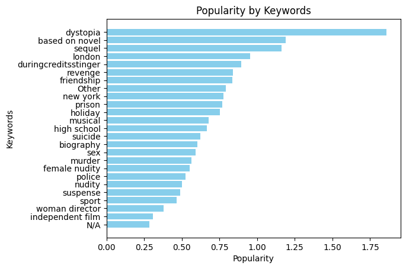

```python
# Popularity by Keywords
plt.barh(keyword_sumarize_sorted_popularity.index, keyword_sumarize_sorted_popularity['popularity'], color='skyblue')
plt.xlabel('Popularity')
plt.ylabel('Keywords')
plt.title('Popularity by Keywords')
plt.gca().invert_yaxis()
plt.show()
```

**The top five** keywords with high popularity are: dystopia, based on novel, sequel, London, and duringcreditsstinger.

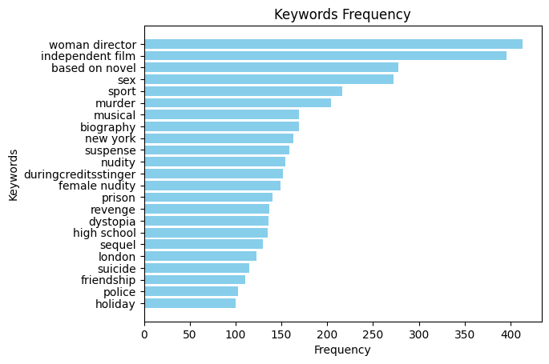

```python
# Keywords frequency
plt.barh(keyword_frequency.index, keyword_frequency.values, color='skyblue')
plt.xlabel('Frequency')
plt.ylabel('Keywords')
plt.title('Keywords Frequency')
plt.gca().invert_yaxis()
plt.show()
```

**The top 5** most mentioned keywords are: woman director, independent film, based on novel, sex, and sport.

# Conclusions

## The steps taken during the data exploration process

1. **Data Wrangling**

:

- Understanding dataset structure, variables, and any inherent patterns or anomalies.
- Identifying and addressing any inconsistencies, missing values, duplicates or errors in the dataset to ensure its accuracy and reliability for analysis.
2. **Exploratory Data Analysis**

:

- Feature Engineering: Creating new columns.
- Univariate Analysis: This involves analyzing individual variables in the dataset to understand their distributions, trends, and relationships with other variables.
- Bivariate Analysis: This involves exploring relationships between pairs of variables in the dataset to identify correlations, associations, or dependencies.
- Visualization: creating visual representations, such as histograms, scatter plots, line chart to visually explore the dataset and identify trends, outliers,...
3. **Documentation and Reporting**

## Analysis Results

1. **Seasonal Trends**
- The analysis indicates **seasonal fluctuations** in revenue and net profit, with **June and December** standing out as the **most profitable months**. Conversely, the **lowest** revenue and net profit are noted in **February**, likely attributed to decreased audience engagement during this time.
- However, the month with the **most movie releases is September**.

=> In summary, revenue and net_profit are influenced by various factors beyond just release numbers. High-profile releases, strategic marketing, audience preferences, and external factors all contribute to the observed trends in revenue and budget.

2. **Financial Analysis:**
- Movie with **higher budgets** generally exhibit **higher revenues and net profits**. Additionally, movies with **higher revenues** tend to yield **greater net profits**.

=> It's important to note that this correlation does not imply causation.

3. **Genre Analysis:**
- **The Adventure genre** tops the charts in terms of revenue, net profit, and popularity, closely followed by Fantasy, Animation, Family, Science Fiction, and Action genres.
- Adventure, Fantasy, Animation, Family, and Action movies are also known for their high budgets.
- Interestingly, **Drama** emerges as **the most produced genre** over the years. This genre consistently ranks among the top 5 with the lowest budgets, possibly contributing to its high production frequency.
4. **Runtime Analysis:**

The analysis reveals the following insights:

- There is a clear trend indicating that movies with **higher popularity** tend to gain **more customer engagement**, as evidenced by their higher vote counts.
- Furthermore, movies with a **substantial number of votes** from customers also demonstrate **higher revenue and net profit**, indicating a positive correlation between customer engagement and financial performance.
6. **Marketing and Promotion**

The analysis uncovers the subsequent insights:

- Movies featuring a **homepage** tend to enjoy **higher popularity**, likely due to increased marketing efforts associated with having a homepage. Additionally, these movies tend to yield **higher revenue and net profit**.
- Conversely, **movies without a homepage** typically operate on **smaller budgets**, potentially reflecting reduced marketing expenditures.
- **The top six keywords** linked to high revenue and profit include sequel, dystopia, based on novel, duringcreditsstinger, holiday, and musical.
- **The top five keywords** associated with high popularity are dystopia, based on novel, sequel, London, and duringcreditsstinger.
- **The top five** most frequently mentioned keywords are woman director, independent film, based on novel, sex, and sport.

## Limitation

1. **Data Quality:**
- The accuracy and completeness of the dataset, including any missing or erroneous data points, could affect the reliability of the analysis and subsequent conclusions.
- The dataset contains over 5000 entries with zero values for revenue and budget, which can significantly distort the analysis outcomes. These zero values may indicate missing or incomplete data, affecting the accuracy of financial performance assessments.
2. **External Factors:**
- This analysis primarily focuses on internal factors such as budget, genre, and runtime, without considering external factors such as competition, economic conditions, or cultural trends, which could also influence movie performance.
3. **Limited Scope:**
- The analysis focuses on specific aspects of movie data, neglecting broader industry dynamics, audience preferences, and evolving market trends, which could provide additional context for understanding financial performance.
4. **Other Considerations:**
- Runtime Analysis:

While I examined the distribution of runtime and its correlation with factors like revenue and popularity, it's crucial to recognize that runtime alone may not fully elucidate audience engagement or financial success.

- Genre Classification: The genre classification may not fully capture the intricacies of movies, as many films belong to multiple genres simultaneously. Furthermore, the analysis doesn't explore how combinations of genres might influence financial performance.

## Additional Information

We can find more useful information within:

1. **Stakeholder Input**: Consult with stakeholders, end-users, or subject matter experts to gather insights into their information needs, priorities, and areas of interest for potential research or additional data collection.
2. **Literature Review:** Conduct a comprehensive review of existing literature, academic research, industry reports, and relevant sources to identify relevant studies, trends, theories, or methodologies that can inform the project and guide further investigation.
3. **External Data Sources:** Investigate external data sources, databases, APIs, or repositories that contain relevant information or complementary datasets that can supplement the project's findings and enhance the analysis.